# Airline Tweets Data Project / Yeoman Yoon

```python
# conda install -c conda-forge spacy
# $ conda update -n base -c defaults conda
```

```python
import re
import numpy as np                                  #for large and multi-dimensional arrays
import pandas as pd                                 #for data manipulation and analysis
import nltk                                         #Natural language processing tool-kit

# nltk.download('stopwords')    #download stopwords
# nltk.download('punkt')

from nltk.corpus import stopwords                   #Stopwords corpus
from nltk.stem import PorterStemmer                 # Stemmer
from nltk.tokenize import word_tokenize

from sklearn.feature_extraction.text import CountVectorizer          #For Bag of words
from sklearn.feature_extraction.text import TfidfVectorizer          #For TF-IDF

# !pip install vaderSentiment    # Install vader sentiment package
# !pip install textblob   # Install textblob package

# install and import necessary libraries.

# !pip install contractions

import string, unicodedata                          # Import Regex, string and unicodedata.
import contractions                                     # Import contractions library.
from bs4 import BeautifulSoup                           # Import BeautifulSoup.

from nltk.corpus import stopwords                       # Import stopwords.
import nltk
nltk.download('stopwords')

from nltk.tokenize import word_tokenize, sent_tokenize  # Import Tokenizer.
from nltk.stem.wordnet import WordNetLemmatizer         # Import Lemmatizer.
import matplotlib.pyplot as plt
from sklearn.model_selection import KFold , StratifiedKFold, cross_val_score
from sklearn.metrics import accuracy_score
import seaborn as sns


from sklearn.ensemble import RandomForestClassifier       # Import Random forest Classifier
from sklearn.metrics import classification_report         # Import Classification report
from sklearn.model_selection import cross_val_score

from wordcloud import WordCloud,STOPWORDS




# Ignore the warnings
import warnings
warnings.filterwarnings("ignore")
```

## Opinion on problem statement:

There are many ways to enhance products and service. Yet, it is most critial to hear customers' voice. Although the platform tweeter may not represent the whole customers, it is a good start to evaluate on the customer reviews and see what can be improved in the product or service.

## Import Data

```python
tweets = pd.read_csv("tweets.csv") # use copy to store the original data
data = tweets.copy()
```

```python
data.head()
```

|  | tweet_id | airline_sentiment | airline_sentiment_confidence | negativereason | negativereason_confidence | airline | airline_sentiment_gold | name | negativereason_gold | retweet_count | text | tweet_coord | tweet_created | tweet_location | user_timezone |
| --- | --- | --- | --- | --- | --- | --- | --- | --- | --- | --- | --- | --- | --- | --- | --- |
| 0 | 570306133677760513 | neutral | 1.0000 | NaN | NaN | Virgin America | NaN | cairdin | NaN | 0 | @VirginAmerica What @dhepburn said. | NaN | 2015-02-24 11:35:52 -0800 | NaN | Eastern Time (US & Canada) |
| 1 | 570301130888122368 | positive | 0.3486 | NaN | 0.0000 | Virgin America | NaN | jnardino | NaN | 0 | @VirginAmerica plus you've added commercials t... | NaN | 2015-02-24 11:15:59 -0800 | NaN | Pacific Time (US & Canada) |
| 2 | 570301083672813571 | neutral | 0.6837 | NaN | NaN | Virgin America | NaN | yvonnalynn | NaN | 0 | @VirginAmerica I didn't today... Must mean I n... | NaN | 2015-02-24 11:15:48 -0800 | Lets Play | Central Time (US & Canada) |
| 3 | 570301031407624196 | negative | 1.0000 | Bad Flight | 0.7033 | Virgin America | NaN | jnardino | NaN | 0 | @VirginAmerica it's really aggressive to blast... | NaN | 2015-02-24 11:15:36 -0800 | NaN | Pacific Time (US & Canada) |
| 4 | 570300817074462722 | negative | 1.0000 | Can't Tell | 1.0000 | Virgin America | NaN | jnardino | NaN | 0 | @VirginAmerica and it's a really big bad thing... | NaN | 2015-02-24 11:14:45 -0800 | NaN | Pacific Time (US & Canada) |

```python
print(f"The data has {data.shape[0]} rows and {data.shape[1]} columns")
```

```
The data has 14640 rows and 15 columns
```

## EDA

```python
data.info()
```

```
<class 'pandas.core.frame.DataFrame'>
RangeIndex: 14640 entries, 0 to 14639
Data columns (total 15 columns):
tweet_id                        14640 non-null int64
airline_sentiment               14640 non-null object
airline_sentiment_confidence    14640 non-null float64
negativereason                  9178 non-null object
negativereason_confidence       10522 non-null float64
airline                         14640 non-null object
airline_sentiment_gold          40 non-null object
name                            14640 non-null object
negativereason_gold             32 non-null object
retweet_count                   14640 non-null int64
text                            14640 non-null object
tweet_coord                     1019 non-null object
tweet_created                   14640 non-null object
tweet_location                  9907 non-null object
user_timezone                   9820 non-null object
dtypes: float64(2), int64(2), object(11)
memory usage: 1.7+ MB
```

```python
data.describe()
```

|  | tweet_id | airline_sentiment_confidence | negativereason_confidence | retweet_count |
| --- | --- | --- | --- | --- |
| count | 1.464000e+04 | 14640.000000 | 10522.000000 | 14640.000000 |
| mean | 5.692184e+17 | 0.900169 | 0.638298 | 0.082650 |
| std | 7.791112e+14 | 0.162830 | 0.330440 | 0.745778 |
| min | 5.675883e+17 | 0.335000 | 0.000000 | 0.000000 |
| 25% | 5.685592e+17 | 0.692300 | 0.360600 | 0.000000 |
| 50% | 5.694779e+17 | 1.000000 | 0.670600 | 0.000000 |
| 75% | 5.698905e+17 | 1.000000 | 1.000000 | 0.000000 |
| max | 5.703106e+17 | 1.000000 | 1.000000 | 44.000000 |

```python
data.nunique().sort_values(ascending=False)
```

```
tweet_id                        14485
text                            14427
tweet_created                   14247
name                             7701
tweet_location                   3081
negativereason_confidence        1410
airline_sentiment_confidence     1023
tweet_coord                       832
user_timezone                      85
retweet_count                      18
negativereason_gold                13
negativereason                     10
airline                             6
airline_sentiment_gold              3
airline_sentiment                   3
dtype: int64
```

### Missing Value Treatment

```python
data.isnull().sum()
```

```
tweet_id                            0
airline_sentiment                   0
airline_sentiment_confidence        0
negativereason                   5462
negativereason_confidence        4118
airline                             0
airline_sentiment_gold          14600
name                                0
negativereason_gold             14608
retweet_count                       0
text                                0
tweet_coord                     13621
tweet_created                       0
tweet_location                   4733
user_timezone                    4820
dtype: int64
```

We have significant amount of missing variables. gold, coord, location , and timezone are irrelatvent in our research. However, negativereason and negativereason_confidence may need more study.

```python
data[data['airline_sentiment']=='negative'].shape
```

```
(9178, 15)
```

```python
data[data['airline_sentiment']=='negative'].isnull().sum()
```

```
tweet_id                           0
airline_sentiment                  0
airline_sentiment_confidence       0
negativereason                     0
negativereason_confidence          0
airline                            0
airline_sentiment_gold          9146
name                               0
negativereason_gold             9146
retweet_count                      0
text                               0
tweet_coord                     8515
tweet_created                      0
tweet_location                  3142
user_timezone                   3170
dtype: int64
```

```python
data[data['airline_sentiment']=='positive'].shape
```

```
(2363, 15)
```

```python
data[data['airline_sentiment']=='positive'].isnull().sum()
```

```
tweet_id                           0
airline_sentiment                  0
airline_sentiment_confidence       0
negativereason                  2363
negativereason_confidence       2033
airline                            0
airline_sentiment_gold          2358
name                               0
negativereason_gold             2363
retweet_count                      0
text                               0
tweet_coord                     2188
tweet_created                      0
tweet_location                   629
user_timezone                    679
dtype: int64
```

```python
data[data['airline_sentiment']=='neutral'].shape
```

```
(3099, 15)
```

```python
data[data['airline_sentiment']=='neutral'].isnull().sum()
```

```
tweet_id                           0
airline_sentiment                  0
airline_sentiment_confidence       0
negativereason                  3099
negativereason_confidence       2085
airline                            0
airline_sentiment_gold          3096
name                               0
negativereason_gold             3099
retweet_count                      0
text                               0
tweet_coord                     2918
tweet_created                      0
tweet_location                   962
user_timezone                    971
dtype: int64
```

```python
# data[data['negativereason_confidence']==0]['airline_sentiment'].nunique() # if negative reason is 0 then it's not negative
# data[data['negativereason_confidence']==0]['airline_sentiment'].shape # 5462-4118 = 1344
```

As expected, negativereason is present only when sentiment is negative. 0s and NaN means the same in negativereason_confidence

### a. Plot the distribution of all tweets among each airline & plot the distribution of sentiment across all the tweets.

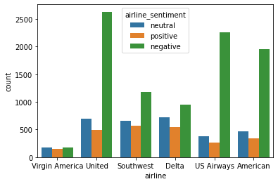

```python
sns.countplot(data['airline'], hue = data['airline_sentiment'])
plt.show()
```

### b. Plot the distribution of Sentiment of tweets for each airline & plot the distribution of all the negative reasons.

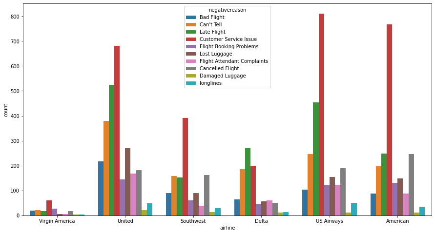

```python
plt.figure(figsize = (15,8))
sns.countplot(data['airline'], hue = data['negativereason'])
plt.show()
```

### c. Plot the word cloud graph of tweets for positive and negative sentiment separately.

```python
negative_only=data[data['airline_sentiment']=='negative']
negative_words = ' '.join(negative_only['text'])
separated_negative_word = ' '.join([word for word in negative_words.split()
                            if 'http' not in word
                                and not word.startswith('@')
                                and word != 'RT'
                            ])
```

```python
negative_wordcloud = WordCloud(stopwords=STOPWORDS,
                      background_color='black',
                      width=3000,
                      height=2500
                     ).generate(separated_negative_word)
```

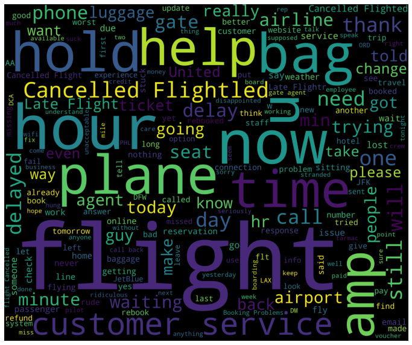

```python
plt.figure(1,figsize=(12, 12))
plt.imshow(negative_wordcloud)
plt.axis('off')
plt.show()
```

```python
positive_only=data[data['airline_sentiment']=='positive']
positive_words = ' '.join(positive_only['text'])
separated_positive_word = ' '.join([word for word in positive_words.split()
                            if 'http' not in word
                                and not word.startswith('@')
                                and word != 'RT'
                            ])
```

```python
positive_wordcloud = WordCloud(stopwords=STOPWORDS,
                      background_color='black',
                      width=3000,
                      height=2500
                     ).generate(separated_positive_word)
```

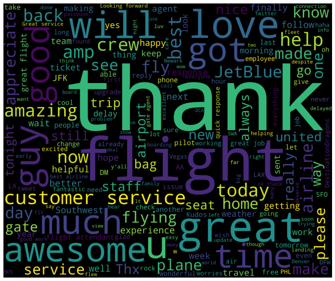

```python
plt.figure(1,figsize=(12, 12))
plt.imshow(positive_wordcloud)
plt.axis('off')
plt.show()
```

## Understand Data

```python
data_original = data # run once
```

```python
data = data[['airline_sentiment','text']]
```

```python
print(f"The data has {data.shape[0]} rows and {data.shape[1]} columns")
```

```
The data has 14640 rows and 2 columns
```

```python
# display all text
pd.set_option('display.max_colwidth', 0) # ?pd.set_option

data.head()
```

|  | airline_sentiment | text |
| --- | --- | --- |
| 0 | neutral | @VirginAmerica What @dhepburn said. |
| 1 | positive | @VirginAmerica plus you've added commercials to the experience... tacky. |
| 2 | neutral | @VirginAmerica I didn't today... Must mean I need to take another trip! |
| 3 | negative | @VirginAmerica it's really aggressive to blast obnoxious "entertainment" in your guests' faces &amp; they have little recourse |
| 4 | negative | @VirginAmerica and it's a really big bad thing about it |

## Text pre-processing

### Cleaning the Text

```python
#remove the html tags
def remove_html(text):
    soup = BeautifulSoup(text, "html.parser")
    return soup.get_text()

#expand the contractions
def replace_contractions(text):
    return contractions.fix(text)

#remove the numericals present in the text
def remove_numbers(text):
  text = re.sub(r'\d+', '', text)
  return text

# remove the url's present in the text
def remove_url(text):
    text = re.sub('http[s]?://(?:[a-zA-Z]|[0-9]|[$-_@.&+]|[!*\(\),]|(?:%[0-9a-fA-F][0-9a-fA-F]))+','',text)
    return text

# remove the mentions in the tweets
def remove_mention(text):
    text = re.sub(r'@\w+','',text)
    return text

def clean_text(text):
    text = remove_html(text)
    text = replace_contractions(text)
    text = remove_numbers(text)
    text = remove_url(text)
    text = remove_mention(text)
    return text

data['text'] = data['text'].apply(lambda x: clean_text(x))
data.head()
```

|  | airline_sentiment | text |
| --- | --- | --- |
| 0 | neutral | What said. |
| 1 | positive | plus you have added commercials to the experience... tacky. |
| 2 | neutral | I did not today... Must mean I need to take another trip! |
| 3 | negative | it is really aggressive to blast obnoxious "entertainment" in your guests' faces & they have little recourse |
| 4 | negative | and it is a really big bad thing about it |

### Tokenization

```python
data['text'] = data.apply(lambda row: nltk.word_tokenize(row['text']), axis=1)
```

### normalization

```python
#remove the non-ASCII characters
def remove_non_ascii(text):
    new_text = []
    for word in text:
        new_word = unicodedata.normalize('NFKD', word).encode('ascii', 'ignore').decode('utf-8', 'ignore')
        new_text.append(new_word)
    return new_text

# convert to lowercase
def to_lowercase(text):
    new_text = []
    for word in text:
        new_word = word.lower()
        new_text.append(new_word)
    return new_text

# Remove the hashtags
def remove_hash(text):
   new_text = []
   for word in text:
     new_word = re.sub(r'#\w+','',word)
     if new_word != '':
       new_text.append(new_word)
   return new_text

# Remove the punctuations
def remove_punctuation(text):
    new_text = []
    for word in text:
        new_word = re.sub(r'[^\w\s]', '', word)
        if new_word != '':
            new_text.append(new_word)
    return new_text

# Remove the stopword
stopwords = stopwords.words('english')
stopwords = list(set(stopwords))
def remove_stopwords(text):
    new_text = []
    for word in text:
        if word not in stopwords:
            new_text.append(word)
    return new_text

# lemmatize the text
lemmatizer = WordNetLemmatizer()
def lemmatize_list(text):
    new_text = []
    for word in text:
      new_text.append(lemmatizer.lemmatize(word, pos='v'))
    return new_text

def normalize(text):
    text = remove_non_ascii(text)
    text = to_lowercase(text)
    text = remove_punctuation(text)
    text = remove_stopwords(text)
    text = lemmatize_list(text)
    return ' '.join(text)

data['text'] = data.apply(lambda row: normalize(row['text']), axis=1)
```

### Print the first 5 rows of data after pre-processing.

```python
data.head()
```

|  | airline_sentiment | text |
| --- | --- | --- |
| 0 | neutral | say |
| 1 | positive | plus add commercials experience tacky |
| 2 | neutral | today must mean need take another trip |
| 3 | negative | really aggressive blast obnoxious entertainment guests face little recourse |
| 4 | negative | really big bad thing |

## Vectorization

### CountVectorizer

```python
# Vectorization (Convert text data to numbers).
from sklearn.feature_extraction.text import CountVectorizer

Count_vec = CountVectorizer(max_features=500) # Keep only 500 features.
text_features = Count_vec.fit_transform(data['text'])

text_features = text_features.toarray() # Convert the data features to array.
```

```python
text_features.shape
```

```
(14640, 500)
```

```python
X = text_features

y = data['airline_sentiment']
```

```python
# Split data into training and testing set.

from sklearn.model_selection import train_test_split

X_train, X_test, y_train, y_test = train_test_split(X, y, test_size=0.25, shuffle=False)
```

```python
# Finding optimal number of base learners using k-fold CV ->
base_ln = np.arange(100,400,100).tolist()
base_ln
```

```
[100, 200, 300]
```

```python
# K-Fold Cross - validation .
cv_scores = []
for b in base_ln:
    clf = RandomForestClassifier(n_estimators = b)
    scores = cross_val_score(clf, X_train, y_train, cv = 5, scoring = 'accuracy')
    cv_scores.append(scores.mean())
```

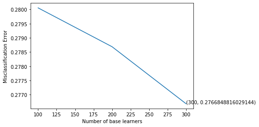

```python
# plotting the error as k increases
error = [1 - x for x in cv_scores]                                 #error corresponds to each nu of estimator
optimal_learners = base_ln[error.index(min(error))]                #Selection of optimal nu of n_estimator corresponds to minimum error.
plt.plot(base_ln, error)                                           #Plot between each nu of estimator and misclassification error
xy = (optimal_learners, min(error))
plt.annotate('(%s, %s)' % xy, xy = xy, textcoords='data')
plt.xlabel("Number of base learners")
plt.ylabel("Misclassification Error")
plt.show()
```

```python
# Training the best model and calculating accuracy on test data .
clf = RandomForestClassifier(n_estimators = optimal_learners)
clf.fit(X_train, y_train)
clf.score(X_test, y_test)
count_vectorizer_predicted = clf.predict(X_test)
print(classification_report(y_test ,count_vectorizer_predicted , target_names = ['positive' , 'neutral', 'negative']))
print("Accuracy of the model is : ",accuracy_score(y_test,count_vectorizer_predicted))
```

[output not shown]

```
[[2252  261  114]
 [ 235  277   65]
 [ 101   64  291]]
```

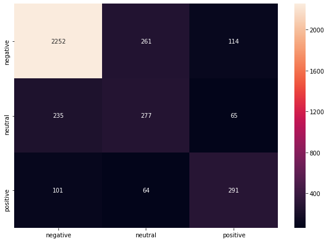

```python
# Print and plot Confusion matirx to get an idea of how the distribution of the prediction is, among all the classes.

import matplotlib.pyplot as plt
import seaborn as sns
from sklearn.metrics import confusion_matrix

conf_mat = confusion_matrix(y_test, count_vectorizer_predicted)

print(conf_mat)

df_cm = pd.DataFrame(conf_mat, index = [i for i in ['negative', 'neutral', 'positive']],
                  columns = [i for i in ['negative', 'neutral', 'positive']])
plt.figure(figsize = (10,7))
sns.heatmap(df_cm, annot=True, fmt='g')
```

```
thank,delay,great,flight,love,get,hours,hold,bag,awesome,cancel,hour,fly,would,amaze,best,please,go,wait,help,make,service,time,customer,worst,plane,call,need,fleek,never,still,one,like,lose,us,say,good,know,miss,airline,
```

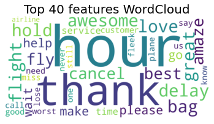

```python
all_features = Count_vec.get_feature_names()              #Instantiate the feature from the vectorizer
top_features=''                                            # Addition of top 40 feature into top_feature after training the model
feat=clf.feature_importances_
features=np.argsort(feat)[::-1]
for i in features[0:40]:
    top_features+=all_features[i]
    top_features+=','

print(top_features)

print(" ")
print(" ")

from wordcloud import WordCloud
wordcloud = WordCloud(background_color="white",colormap='viridis',width=2000,
                          height=1000).generate(top_features)

# Display the generated image:
plt.imshow(wordcloud, interpolation='bilinear')
plt.figure(1, figsize=(14, 11), frameon='equal')
plt.title('Top 40 features WordCloud', fontsize=20)
plt.axis("off")
plt.show()
```

```python
# Using TfidfVectorizer to convert text data to numbers.

from sklearn.feature_extraction.text import TfidfVectorizer

tfidf_vect = TfidfVectorizer(max_features=500)
text_features = tfidf_vect.fit_transform(data['text'])

text_features = text_features.toarray()

text_features.shape     #feature shape
```

```
(14640, 500)
```

```python
X = text_features

y = data['airline_sentiment']
```

```python
# Split data into training and testing set.

from sklearn.model_selection import train_test_split

X_train, X_test, y_train, y_test = train_test_split(X, y, test_size=0.25, shuffle=False)
```

```python
# Finding optimal number of base learners using k-fold CV ->
base_ln = np.arange(100,400,100).tolist()
base_ln
```

```
[100, 200, 300]
```

```python
# K-Fold Cross - validation .
cv_scores = []
for b in base_ln:
    clf = RandomForestClassifier(n_estimators = b)
    scores = cross_val_score(clf, X_train, y_train, cv = 5, scoring = 'accuracy')
    cv_scores.append(scores.mean())
```

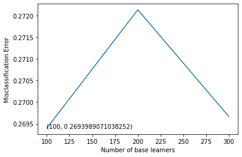

```python
# plotting the error as k increases
error = [1 - x for x in cv_scores]                                 #error corresponds to each nu of estimator
optimal_learners = base_ln[error.index(min(error))]                #Selection of optimal nu of n_estimator corresponds to minimum error.
plt.plot(base_ln, error)                                           #Plot between each nu of estimator and misclassification error
xy = (optimal_learners, min(error))
plt.annotate('(%s, %s)' % xy, xy = xy, textcoords='data')
plt.xlabel("Number of base learners")
plt.ylabel("Misclassification Error")
plt.show()
```

```python
# Training the best model and calculating accuracy on test data .
clf = RandomForestClassifier(n_estimators = optimal_learners)
clf.fit(X_train, y_train)
clf.score(X_test, y_test)
tf_idf_predicted = clf.predict(X_test)
print(classification_report(y_test , tf_idf_predicted , target_names = ['negative', 'neutral', 'positive']))
print("Accuracy of the model is : ",accuracy_score(y_test,tf_idf_predicted))
```

```
              precision    recall  f1-score   support

    negative       0.85      0.90      0.88      2627
     neutral       0.54      0.43      0.48       577
    positive       0.67      0.62      0.64       456

    accuracy                           0.79      3660
   macro avg       0.69      0.65      0.66      3660
weighted avg       0.78      0.79      0.78      3660

Accuracy of the model is :  0.7915300546448087
```

```
[[2368  172   87]
 [ 275  248   54]
 [ 136   39  281]]
```

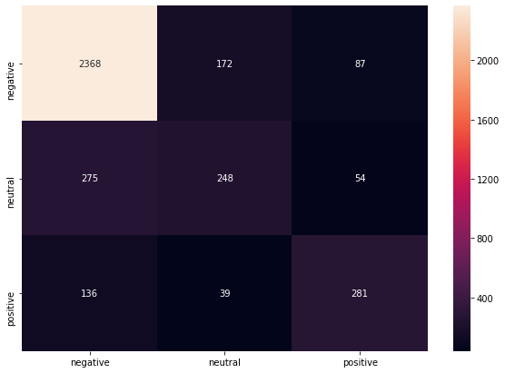

```python
# Print and plot Confusion matirx to get an idea of how the distribution of the prediction is, among all the classes.

import matplotlib.pyplot as plt
import seaborn as sns
from sklearn.metrics import confusion_matrix

conf_mat = confusion_matrix(y_test, tf_idf_predicted)

print(conf_mat)

df_cm = pd.DataFrame(conf_mat, index = [i for i in ['negative', 'neutral', 'positive']],
                  columns = [i for i in ['negative', 'neutral', 'positive']])
plt.figure(figsize = (10,7))
sns.heatmap(df_cm, annot=True, fmt='g')
```

```
thank, flight, great, delay, love, get, hours, bag, awesome, hold, cancel, fly, best, hour, amaze, please, time, make, service, need, would, fleek, help, know, go, wait, plane, fleet, follow, customer, airline, call, good, dm, still, tomorrow, worst, say, us, like,
```

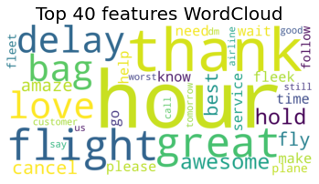

```python
all_features = tfidf_vect.get_feature_names()              #Instantiate the feature from the vectorizer
top_features=''                                            # Addition of top 40 feature into top_feature after training the model
feat=clf.feature_importances_
features=np.argsort(feat)[::-1]
for i in features[0:40]:
    top_features+=all_features[i]
    top_features+=', '

print(top_features)

print(" ")
print(" ")

from wordcloud import WordCloud
wordcloud = WordCloud(background_color="white",colormap='viridis',width=2000,
                          height=1000).generate(top_features)

# Display the generated image:
plt.imshow(wordcloud, interpolation='bilinear')
plt.figure(1, figsize=(14, 11), frameon='equal')
plt.title('Top 40 features WordCloud', fontsize=20)
plt.axis("off")
plt.show()
```

### Compare

```python
#convert the test samples
df = pd.DataFrame(y_test.tolist(),columns =['y_test'])
df['count_vectorizer_predicted'] = count_vectorizer_predicted
df['tf_idf_predicted'] = tf_idf_predicted
df.head()
```

|  | y_test | count_vectorizer_predicted | tf_idf_predicted |
| --- | --- | --- | --- |
| 0 | negative | negative | negative |
| 1 | negative | negative | negative |
| 2 | negative | negative | negative |
| 3 | negative | negative | negative |
| 4 | positive | negative | negative |

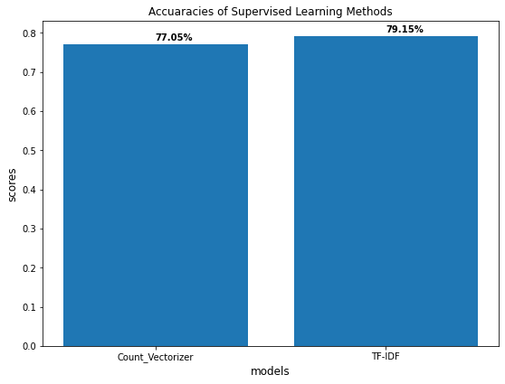

```python
#compare the accuaracies of Count Vectorizer and TF-IDF
import matplotlib.pyplot as plt
fig = plt.figure(figsize=(7,5))
ax = fig.add_axes([0,0,1,1])
subjects = ['Count_Vectorizer', 'TF-IDF']

# Count Vectorizer and TF-IDF using accuracy_score metrics
scores = [accuracy_score(y_test,count_vectorizer_predicted),accuracy_score(y_test,tf_idf_predicted)]
ax.bar(subjects,scores)
ax.set_ylabel('scores',fontsize= 12)
ax.set_xlabel('models',fontsize= 12)
ax.set_title('Accuaracies of Supervised Learning Methods')  # title
for i, v in enumerate(scores):
    ax.text( i ,v+0.01, '{:.2f}%'.format(100*v), color='black', fontweight='bold')
    plt.savefig('barplot_1.png',dpi=100, format='png', bbox_inches='tight')
plt.show()
```

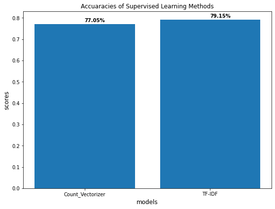

```python
# compare the accuaracies of Count Vectorizer and TF-IDF
import matplotlib.pyplot as plt
fig = plt.figure(figsize=(7,5))
ax = fig.add_axes([0,0,1,1])
subjects = ['Count_Vectorizer', 'TF-IDF']

# Count Vectorizer and TF-IDF using accuracy_score metrics
scores = [accuracy_score(y_test,count_vectorizer_predicted),accuracy_score(y_test,tf_idf_predicted)]
ax.bar(subjects,scores)
ax.set_ylabel('scores',fontsize= 12)
ax.set_xlabel('models',fontsize= 12)
ax.set_title('Accuaracies of Supervised Learning Methods')  # title
for i, v in enumerate(scores):
    ax.text( i ,v+0.01, '{:.2f}%'.format(100*v), color='black', fontweight='bold')
    plt.savefig('barplot_1.png',dpi=100, format='png', bbox_inches='tight')
plt.show()
```

## Conclusion:

although the nlp may not be accurate as human manual reading, it is significantly required since review text is so huge. In order to improve, airlines must consider the @mention of other people agreeing the other users, sarcasm of users, emojis used, and all caps. tweets or other reviews outside of the original platform lack the rating level therefore must consider nlp to interpret customer needs.

### Understading of NLP:

As a person who speaks Korean, I thought of how NLP could be applied to Korean language. The difficulty lies on slang, no punctuations and frequent error of space bar (For English every words are separated by space, yet in Korean space is very tricky that people may be wrong extremely frequently.). I think every language has its characters, tone and mood of the text may not be easily interpreted by machine (e.g good, not good, not bad, bad, good enough etc. may have different standards for people) finding numeric scales of the text must be enhanced with bigger data and patterns.